# automatization_notebook_03

2023-11-16

# Чтение данных +

> Данные читаются и прочитаны корректно

```r
framingham <- read_csv ("framingham.csv")
```

# Общее описание данных +

Используемые данные находятся в открытом доступе на сайте [kaggle.com](https://www.kaggle.com/datasets/dileep070/heart-disease-prediction-using-logistic-regression/). Анализируемый датасет содержит информацию о более чем 4 тысячах жителей города Framingham (Massachusetts, USA), включающую различные потенциальные факторы риска и исход (диагностирование или нет ишемической болезни сердца в течение 10 лет наблюдения).

```r
framingham %>%
  summary ()
```

```
##       male             age          education     currentSmoker
##  Min.   :0.0000   Min.   :32.00   Min.   :1.000   Min.   :0.0000
##  1st Qu.:0.0000   1st Qu.:42.00   1st Qu.:1.000   1st Qu.:0.0000
##  Median :0.0000   Median :49.00   Median :2.000   Median :0.0000
##  Mean   :0.4292   Mean   :49.58   Mean   :1.979   Mean   :0.4941
##  3rd Qu.:1.0000   3rd Qu.:56.00   3rd Qu.:3.000   3rd Qu.:1.0000
##  Max.   :1.0000   Max.   :70.00   Max.   :4.000   Max.   :1.0000
##                                   NA's   :105
##    cigsPerDay         BPMeds        prevalentStroke     prevalentHyp
##  Min.   : 0.000   Min.   :0.00000   Min.   :0.000000   Min.   :0.0000
##  1st Qu.: 0.000   1st Qu.:0.00000   1st Qu.:0.000000   1st Qu.:0.0000
##  Median : 0.000   Median :0.00000   Median :0.000000   Median :0.0000
##  Mean   : 9.003   Mean   :0.02963   Mean   :0.005899   Mean   :0.3105
##  3rd Qu.:20.000   3rd Qu.:0.00000   3rd Qu.:0.000000   3rd Qu.:1.0000
##  Max.   :70.000   Max.   :1.00000   Max.   :1.000000   Max.   :1.0000
##  NA's   :29       NA's   :53
##     diabetes          totChol          sysBP           diaBP
##  Min.   :0.00000   Min.   :107.0   Min.   : 83.5   Min.   : 48.00
##  1st Qu.:0.00000   1st Qu.:206.0   1st Qu.:117.0   1st Qu.: 75.00
##  Median :0.00000   Median :234.0   Median :128.0   Median : 82.00
##  Mean   :0.02572   Mean   :236.7   Mean   :132.4   Mean   : 82.89
##  3rd Qu.:0.00000   3rd Qu.:263.0   3rd Qu.:144.0   3rd Qu.: 89.88
##  Max.   :1.00000   Max.   :696.0   Max.   :295.0   Max.   :142.50
##                    NA's   :50
##       BMI          heartRate         glucose         TenYearCHD
##  Min.   :15.54   Min.   : 44.00   Min.   : 40.00   Min.   :0.000
##  1st Qu.:23.07   1st Qu.: 68.00   1st Qu.: 71.00   1st Qu.:0.000
##  Median :25.40   Median : 75.00   Median : 78.00   Median :0.000
##  Mean   :25.80   Mean   : 75.88   Mean   : 81.97   Mean   :0.152
##  3rd Qu.:28.04   3rd Qu.: 83.00   3rd Qu.: 87.00   3rd Qu.:0.000
##  Max.   :56.80   Max.   :143.00   Max.   :394.00   Max.   :1.000
##  NA's   :19      NA's   :1        NA's   :388
```

# Очистка данных

## Поиск переменных с долей пропущенных значений более 20% +

> Код работает и написан верно и оптимально

```r
framingham_more_than_20_cols <- framingham %>%
  select (where (function(x) sum (is.na(x))/ nrow(framingham) * 100 > 20))
  ifelse (ncol (framingham_more_than_20_cols) > 0,
          framingham_more_than_20_cols,
          "Переменных с долей пропущенных значений более 20% не выявлено")
```

```
## [1] "Переменных с долей пропущенных значений более 20% не выявлено"
```

## Поиск субъектов со слишком большим количеством пропущенных значений +

> Вычисления проведены верно

```r
  framingham_shortened <- framingham [apply (framingham, 1, function(x) sum (is.na(x))/ ncol (framingham) * 100 < 10), ]
```

*Выбраны субъекты с долей пропущенных значений менее 10%*

## Переименовывание, приведение переменных к нужному типу, сортировка по возрасту +

> Преобразования проведены верно и оптимально

```r
cleaned_data <- framingham_shortened %>%
  rename (Male = male, Age = age, Education = education,
        'Current Smoker'= currentSmoker, 'Cigarettes per day' = cigsPerDay,
        'Blood pressure medication' = BPMeds, 'Stroke in history'= prevalentStroke,
        'Hypertension in history' = prevalentHyp, 'Diabets in history' = diabetes,
        'Total cholesterol' = totChol, 'Systolic blood pressure' = sysBP,
        'Diastolic blood pressure' = diaBP, 'Heart rate' = heartRate,
        Glucose = glucose, '10 year risk of CHD' = TenYearCHD) %>%
  mutate_at (c('Male', 'Education', 'Current Smoker', 'Blood pressure medication',
              'Stroke in history', 'Hypertension in history', 'Diabets in history',
              '10 year risk of CHD'), as.factor) %>%
  mutate_at (c('Age','Cigarettes per day', 'Total cholesterol', 'Systolic blood pressure',
               'Diastolic blood pressure', 'BMI', 'Heart rate', 'Glucose'), as.numeric) %>%
  arrange (desc (Age))
```

## Создание файла outliers.csv с субъектами, которые являются выбросами +

> Вычисления проведены верно - фильтрация по правилу трёх сигм является хорошим вариантом

```r
outliers <- cleaned_data %>%
  mutate_at (c('Male', 'Education', 'Current Smoker', 'Blood pressure medication',
              'Stroke in history', 'Hypertension in history', 'Diabets in history',
              '10 year risk of CHD'), as.numeric) %>%
  filter(if_any(.cols = everything(), .fns = function(x) abs(x - mean(x, na.rm = TRUE)) > 3*sd(x, na.rm = TRUE)))

write_csv (outliers, "outliers.csv")
```

# Сколько осталось переменных? +

> Простой, но эффективный метод

```r
ncol(cleaned_data)
```

```
## [1] 16
```

# Сколько осталось случаев? +

> Простой, но эффективный метод

```r
nrow (cleaned_data)
```

```
## [1] 4177
```

# Есть ли в данных идентичные строки? +

```r
paste ("В данных",  sum (duplicated (cleaned_data)), "повторяющихся строк")
```

```
## [1] "В данных 0 повторяющихся строк"
```

# Сколько всего переменных с пропущенными значениями в данных и сколько пропущенных точек в каждой такой переменной? +

> Вычисления проведены верно и достаточно оптимально

```r
paste("В данных",
      ncol(cleaned_data %>% select(where(anyNA))),
         "переменных с пропущенными значениями")
```

```
## [1] "В данных 7 переменных с пропущенными значениями"
```

Ниже представлено количество пропущенных точек в каждой из таких переменных

```r
cleaned_data %>%
  select(where(anyNA)) %>%
  sapply (function (x) sum(is.na(x)))
```

```
##                 Education        Cigarettes per day Blood pressure medication
##                        93                        23                        51
##         Total cholesterol                       BMI                Heart rate
##                         9                        13                         1
##                   Glucose
##                       331
```

# Описательные статистики

## Количественные переменные +

> Все описательные статистики посчитаны и оформлены верно и эффективно

```r
statistics <- list(
      `Количество субъектов` = ~length(.x) %>% as.character(),
      `Количество пропущенных значений` = ~sum(is.na(.x)) %>% as.character(),
      `Среднее` = ~ifelse(sum(!is.na(.x)) == 0, "Н/П*", mean(.x, na.rm = TRUE) %>% round(2) %>% as.character()),
      `Станд. отклон.` = ~ifelse(sum(!is.na(.x)) < 3, "Н/П*", sd(.x, na.rm = TRUE) %>% round(2) %>% as.character()),
      `мин. - макс.` = ~ifelse(sum(!is.na(.x)) == 0, "Н/П*", paste0(min(.x, na.rm = TRUE) %>% round(2), " - ", max(.x, na.rm = TRUE) %>% round(2))),
      `Медиана` = ~ifelse(sum(!is.na(.x)) == 0, "Н/П*", median(.x, na.rm = TRUE) %>% round(2) %>% as.character()),
      `Q1 - Q3` = ~ifelse(sum(!is.na(.x)) == 0, "Н/П*", paste0(quantile(.x, 0.25, na.rm = TRUE) %>% round(2), " - ", quantile(.x, 0.75, na.rm = TRUE) %>% round(2))),
      `Межквартильный размах` = ~ifelse(sum(!is.na(.x)) == 0, "Н/П*", IQR(.x, na.rm = TRUE) %>% round(2) %>% as.character())
)

cleaned_data %>%
  select('10 year risk of CHD', where(is.numeric)) %>%
  group_by (`10 year risk of CHD`) %>%
  summarise(across(where(is.numeric), statistics)) %>%
  mutate_at (1:ncol(cleaned_data), as.character) %>%
  pivot_longer(!'10 year risk of CHD') %>%
  separate(name, into = c('Переменная', 'Статистика'), sep = '_') %>%
  rename ('Значение' = value) %>%
  flextable() %>%
  theme_box() %>%
  merge_v(c("10 year risk of CHD", "Переменная")) %>%
  width(j= "Статистика", width=3) %>%
  align (j = c("10 year risk of CHD", "Переменная"), align = "center")
```

| 10 year risk of CHD | Переменная | Статистика | Значение |
| --- | --- | --- | --- |
| 0 | Age | Количество субъектов | 3545 |
|  |  | Количество пропущенных значений | 0 |
|  |  | Среднее | 48.72 |
|  |  | Станд. отклон. | 8.39 |
|  |  | мин. - макс. | 32 - 70 |
|  |  | Медиана | 48 |
|  |  | Q1 - Q3 | 42 - 55 |
|  |  | Межквартильный размах | 13 |
|  | Cigarettes per day | Количество субъектов | 3545 |
|  |  | Количество пропущенных значений | 21 |
|  |  | Среднее | 8.68 |
|  |  | Станд. отклон. | 11.67 |
|  |  | мин. - макс. | 0 - 70 |
|  |  | Медиана | 0 |
|  |  | Q1 - Q3 | 0 - 20 |
|  |  | Межквартильный размах | 20 |
|  | Total cholesterol | Количество субъектов | 3545 |
|  |  | Количество пропущенных значений | 8 |
|  |  | Среднее | 235.17 |
|  |  | Станд. отклон. | 43.83 |
|  |  | мин. - макс. | 113 - 696 |
|  |  | Медиана | 232 |
|  |  | Q1 - Q3 | 205 - 261 |
|  |  | Межквартильный размах | 56 |
|  | Systolic blood pressure | Количество субъектов | 3545 |
|  |  | Количество пропущенных значений | 0 |
|  |  | Среднее | 130.3 |
|  |  | Станд. отклон. | 20.38 |
|  |  | мин. - макс. | 83.5 - 243 |
|  |  | Медиана | 127 |

[output cut: 98 more lines]

## Категориальные переменные ++

> Выполнены все задания, кроме дополнительного. Расчеты проведены верно

#### 10-летний риск ИБС и пол

```r
cleaned_data %>%
  select('10 year risk of CHD', Male) %>%
  count (`10 year risk of CHD`, Male) %>%
  group_by (`10 year risk of CHD`) %>%
  mutate ('Relative quantity' = (n/sum(n)) %>% round (3) %>% `*` (100) %>% str_c ("%")) %>%
  rename ('Absolute quantity' = n) %>%
  flextable() %>% theme_box() %>%
  merge_v("10 year risk of CHD") %>%
  align (align = "center") %>%
  set_caption ("Numbers of people depending on '10 year risk of CHD' and 'Male gender'")
```

Numbers of people depending on '10 year risk of CHD' and 'Male gender'

| 10 year risk of CHD | Male | Absolute quantity | Relative quantity |
| --- | --- | --- | --- |
| 0 | 0 | 2,079 | 58.6% |
|  | 1 | 1,466 | 41.4% |
| 1 | 0 | 292 | 46.2% |
|  | 1 | 340 | 53.8% |

#### 10-летний риск ИБС и образование

```r
cleaned_data %>%
  select('10 year risk of CHD', Education) %>%
  mutate (`Education` = `Education` %>% as.character() %>% replace_na ("Нет данных") %>% as.factor()) %>%
  count (`10 year risk of CHD`, Education) %>%
  group_by (`10 year risk of CHD`) %>%
  mutate ('Relative quantity' = (n/sum(n)) %>% round (3) %>% `*` (100) %>% str_c ("%")) %>%
  rename ('Absolute quantity' = n) %>%
  flextable() %>% theme_box() %>%
  merge_v("10 year risk of CHD") %>%
  align (align = "center") %>%
  set_caption ("Numbers of people depending on '10 year risk of CHD' and 'Education'")
```

Numbers of people depending on '10 year risk of CHD' and 'Education'

| 10 year risk of CHD | Education | Absolute quantity | Relative quantity |
| --- | --- | --- | --- |
| 0 | 1 | 1,381 | 39% |
|  | 2 | 1,095 | 30.9% |
|  | 3 | 592 | 16.7% |
|  | 4 | 399 | 11.3% |
|  | Нет данных | 78 | 2.2% |
| 1 | 1 | 319 | 50.5% |
|  | 2 | 142 | 22.5% |
|  | 3 | 87 | 13.8% |
|  | 4 | 69 | 10.9% |
|  | Нет данных | 15 | 2.4% |

#### 10-летний риск ИБС и курение

```r
cleaned_data %>%
  select('10 year risk of CHD', `Current Smoker`) %>%
  count (`10 year risk of CHD`, `Current Smoker`) %>%
  group_by (`10 year risk of CHD`) %>%
  mutate ('Relative quantity' = (n/sum(n)) %>% round (3) %>% `*` (100) %>% str_c ("%")) %>%
  rename ('Absolute quantity' = n) %>%
  flextable() %>% theme_box() %>%
  merge_v("10 year risk of CHD") %>%
  align (align = "center")  %>%
  set_caption ("Numbers of people depending on '10 year risk of CHD' and Smoking status")
```

Numbers of people depending on '10 year risk of CHD' and Smoking status

| 10 year risk of CHD | Current Smoker | Absolute quantity | Relative quantity |
| --- | --- | --- | --- |
| 0 | 0 | 1,816 | 51.2% |
|  | 1 | 1,729 | 48.8% |
| 1 | 0 | 305 | 48.3% |
|  | 1 | 327 | 51.7% |

# Визуализация

## Количественные переменные +

#### 10-летний риск ИБС и возраст

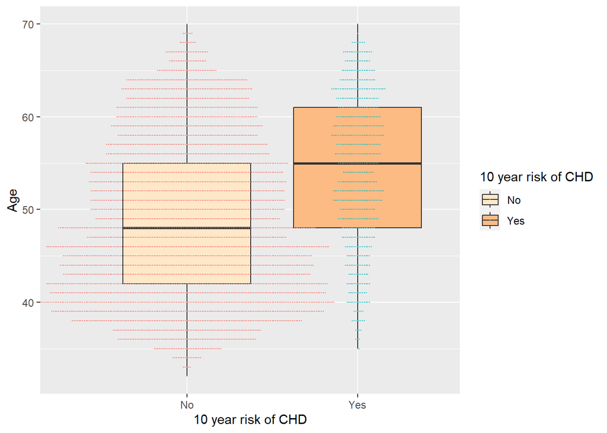

```r
library (ggplot2)
library(RColorBrewer)
library(ggbeeswarm)

numeric_data <- cleaned_data %>%
  select (`10 year risk of CHD`, where (is.numeric)) %>%
  mutate (`10 year risk of CHD` = ifelse (`10 year risk of CHD` == 1, "Yes", "No"))

numeric_data %>%
ggplot (aes(x = `10 year risk of CHD`, y = Age)) +
  geom_boxplot(aes (fill =`10 year risk of CHD`)) +
  geom_beeswarm(size=0.1, cex = 0.5, aes (color = `10 year risk of CHD`)) +
  scale_fill_brewer(palette="OrRd")
```

#### 10-летний риск ИБС и количество сигарет в день

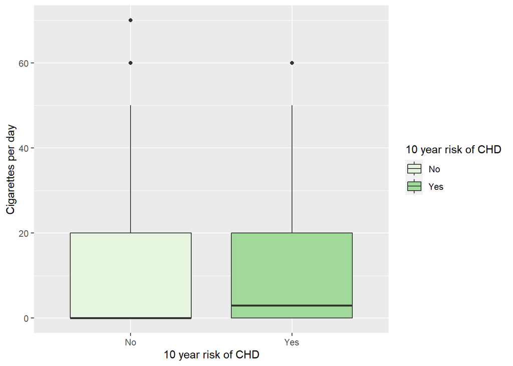

```r
library (ggplot2)
library(RColorBrewer)

ggplot (numeric_data, aes(x = `10 year risk of CHD`, y = `Cigarettes per day`, fill =`10 year risk of CHD`)) +
  geom_boxplot(na.rm = T) +
  scale_fill_brewer(palette="Greens")
```

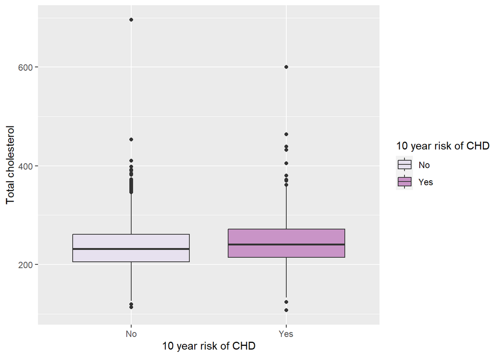

```r
library (ggplot2)
library(RColorBrewer)

ggplot (numeric_data, aes(x = `10 year risk of CHD`, y = `Total cholesterol`, fill =`10 year risk of CHD`)) +
  geom_boxplot(na.rm = T) +
  scale_fill_brewer(palette="PuRd")
```

## Категориальные переменные

1. Сделайте подходящие визуализации категориальных переменных. Обоснуйте, почему выбрали именно этот тип. +

> Столбчатая диаграмма в данном контексте очень подходит так как может отобразить и количество, и пропорции

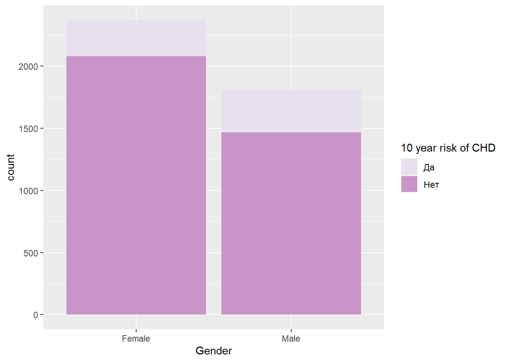

```r
library (ggplot2)
library(RColorBrewer)

categorical_data <- cleaned_data %>%
  select(`10 year risk of CHD`, where(is.factor)) %>%
  mutate (`10 year risk of CHD` = ifelse (`10 year risk of CHD` == 1, "Да", "Нет")) %>%
  rename (Gender = Male) %>%
  mutate (`Gender` = ifelse (`Gender` == 1, "Male", "Female"))


ggplot (categorical_data, aes(x = `Gender`, fill =`10 year risk of CHD`)) +
  geom_bar (na.rm = T) +
  scale_fill_brewer(palette="PuRd")
```

# Статистические оценки

## Проверка на нормальность

1. Оценка переменных на соответствие нормальному распределению с помощью теста Шапиро-Уилка +

> Корректнее говорить “мы не можем отвергнуть нулевую гипотезу о нормальном распределении”, но в целом верно

```r
shapiro_p <- cleaned_data %>%
  mutate_at (c('Male', 'Education', 'Current Smoker', 'Blood pressure medication', 'Stroke in history', 'Hypertension in history', 'Diabets in history', '10 year risk of CHD'), as.numeric) %>%
  summarise(across (where (is.numeric),
            function (x) shapiro.test(x)$p)) %>%
  select(where (function(x) sum (x) > 0.05))

ifelse (ncol (shapiro_p) == 0, "В датасете данные всех переменнных распределены нормально, т.к. отсутствуют переменные, для которых p.value, полученное с помощью теста Шапиро–Уилка, менее 0.05", "В данных имеются переменные, распределение которых значимо отличается от нормального")
```

[output not shown]

2. QQ-плоты для каждой количественной переменной +

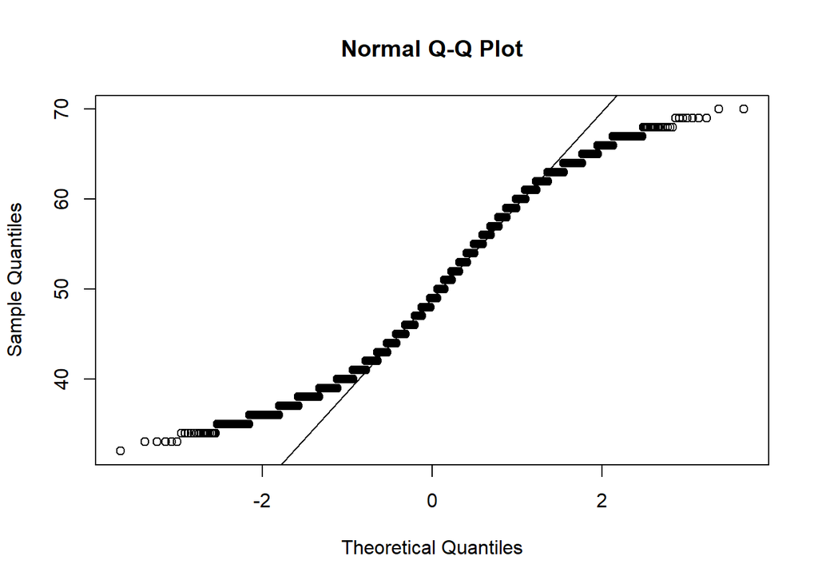

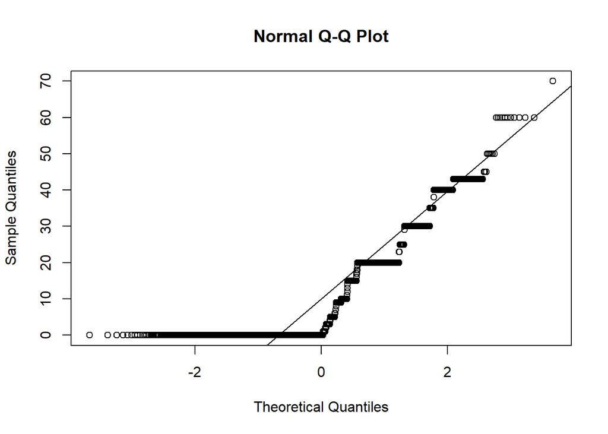

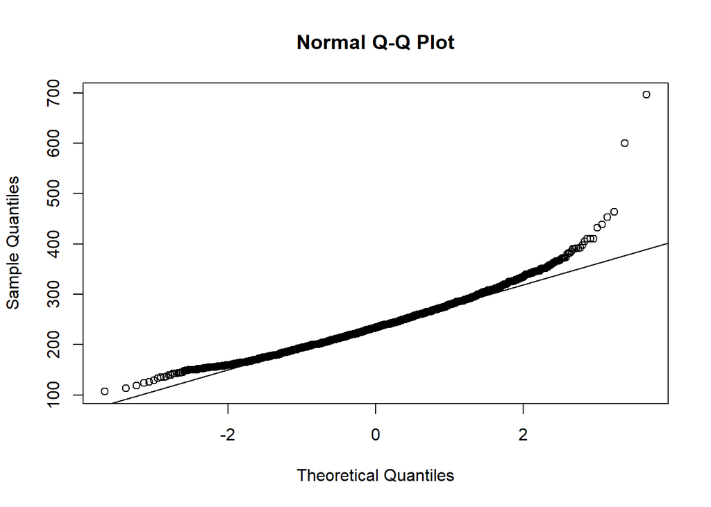

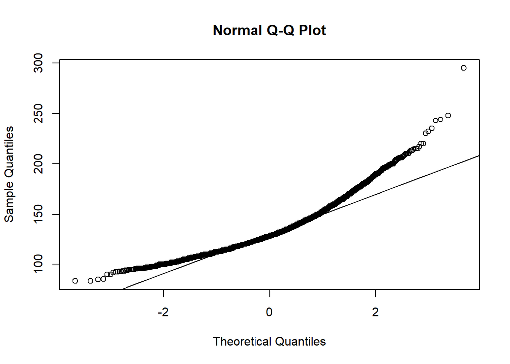

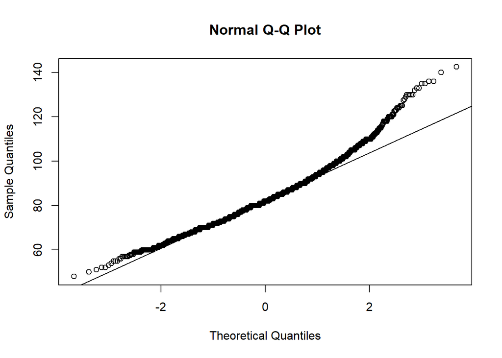

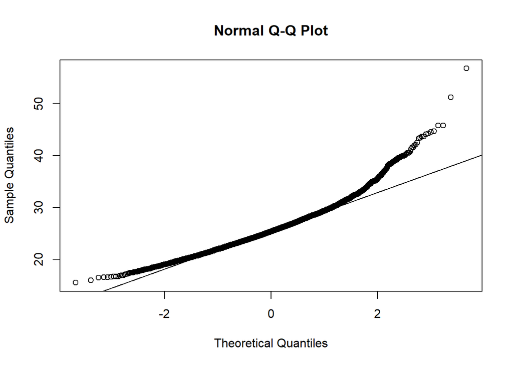

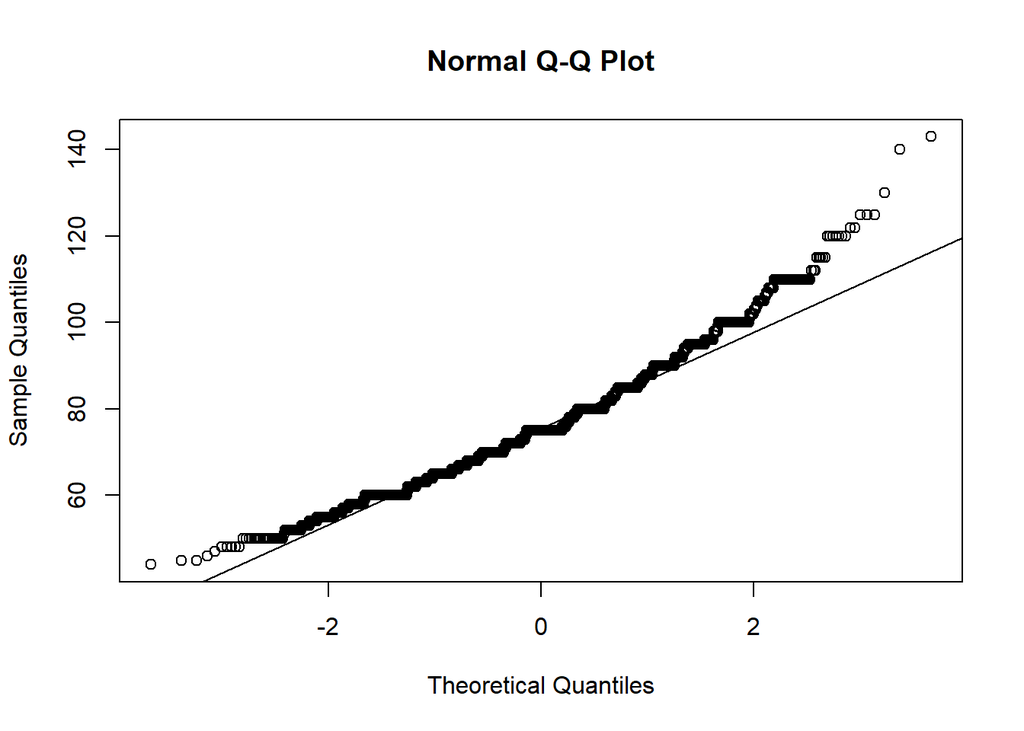

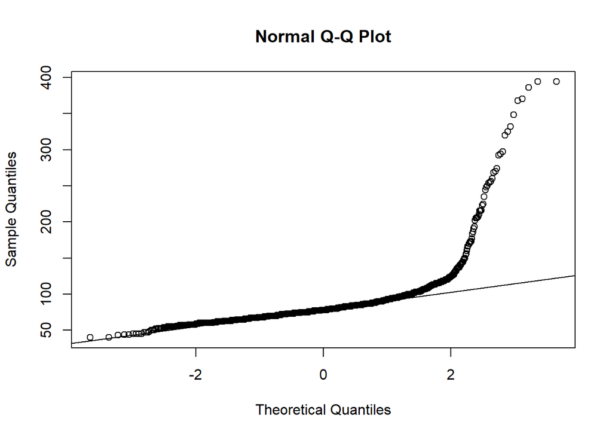

```
##   Age          Cigarettes per day Total cholesterol Systolic blood pressure
## x numeric,4177 numeric,4177       numeric,4177      numeric,4177
## y numeric,4177 numeric,4177       numeric,4177      numeric,4177
##   Diastolic blood pressure BMI          Heart rate   Glucose
## x numeric,4177             numeric,4177 numeric,4177 numeric,4177
## y numeric,4177             numeric,4177 numeric,4177 numeric,4177
```

```r
cleaned_data %>%
  select(where (is.numeric)) %>%
  sapply (function(x) c (qqnorm(x), qqline (x)))
```

*QQ-плот для переменной Glucose демонстрирует явное отклонение распределения от нормального. На мой взгляд, использование теста Шапиро–Уилка боллее предпочтительно, так как он лишен субъективности.*

*Минус теста Шапиро–Уилка в том, что он высокочувствителен к небольшим отклонениям от нормального распределения при больших размерах выборки.*

**1. Построение гистограммы с помощью *hist (x)***

- **метод субъективен**

**2. Тест Колмогорова Смирнова с помощью *ks.test (x, ‘pnorm’)***

- **необходима выборка размером более 50**

> Приведены 2 метода и их ограничения

## Сравнение групп по 10 year risk of CHD +

> Применение t-test для количественных и chisquare для категориальных переменных обосновано

```r
options (scipen = 999)
cleaned_data %>%
  select('10 year risk of CHD', where(is.numeric)) %>%
  summarise(across(where(is.numeric), function(x)
    t.test (x ~ `10 year risk of CHD`)$p.value)) %>%
  round(3) %>%
  summarise(across(where(is.numeric), function(x)
    ifelse (x < 0.001, "< 0.001", x))) %>%
  flextable() %>% theme_box() %>%
  bold (i = 1, j = c(1,2,3,4,5,6,8), part = "body") %>%
  set_caption ("Results (p values) of comparing numerical variables by t.test")
```

Results (p values) of comparing numerical variables by t.test

| Age | Cigarettes per day | Total cholesterol | Systolic blood pressure | Diastolic blood pressure | BMI | Heart rate | Glucose |
| --- | --- | --- | --- | --- | --- | --- | --- |
| < 0.001 | < 0.001 | < 0.001 | < 0.001 | < 0.001 | < 0.001 | 0.144 | < 0.001 |

```r
options (scipen = 999)
cleaned_data %>%
  select('10 year risk of CHD', where(is.factor)) %>%
  mutate('10 year risk of CHD' = as.character('10 year risk of CHD')) %>%
  summarise(across(where(is.factor),
                   function(x) chisq.test (table (x, `10 year risk of CHD`))$p.value)) %>%
  round(3) %>%
  summarise(across(where(is.numeric), function(x)
    ifelse (x < 0.001, "< 0.001", x))) %>%
  flextable() %>% theme_box() %>%
  bold (i = 1, j = c(1,2,4,5,6,7), part = "body") %>%
  set_caption ("Results (p values) of comparing categorical variables by chisq.test")
```

Results (p values) of comparing categorical variables by chisq.test

| Male | Education | Current Smoker | Blood pressure medication | Stroke in history | Hypertension in history | Diabets in history |
| --- | --- | --- | --- | --- | --- | --- |
| < 0.001 | < 0.001 | 0.315 | < 0.001 | < 0.001 | < 0.001 | < 0.001 |

## Корреляционный анализ

### Корреляционная матрица

```r
library (psych)
options (scipen = 999)

as.data.frame(
  (cleaned_data %>%
  select(where(is.numeric)) %>%
  corr.test(adjust = "bonferroni"))$r %>% round (2)
  )
```

|  | Age | Cigarettes per day | Total cholesterol | Systolic blood pressure | Diastolic blood pressure | BMI | Heart rate | Glucose |
| --- | --- | --- | --- | --- | --- | --- | --- | --- |
| Age | 1.00 | -0.19 | 0.26 | 0.39 | 0.20 | 0.13 | -0.01 | 0.12 |
| Cigarettes per day | -0.19 | 1.00 | -0.03 | -0.09 | -0.05 | -0.09 | 0.07 | -0.06 |
| Total cholesterol | 0.26 | -0.03 | 1.00 | 0.21 | 0.17 | 0.12 | 0.09 | 0.05 |
| Systolic blood pressure | 0.39 | -0.09 | 0.21 | 1.00 | 0.78 | 0.33 | 0.18 | 0.14 |
| Diastolic blood pressure | 0.20 | -0.05 | 0.17 | 0.78 | 1.00 | 0.38 | 0.18 | 0.06 |
| BMI | 0.13 | -0.09 | 0.12 | 0.33 | 0.38 | 1.00 | 0.07 | 0.09 |
| Heart rate | -0.01 | 0.07 | 0.09 | 0.18 | 0.18 | 0.07 | 1.00 | 0.09 |
| Glucose | 0.12 | -0.06 | 0.05 | 0.14 | 0.06 | 0.09 | 0.09 | 1.00 |

```r
library (psych)
options (scipen = 999)

as.data.frame ((cleaned_data %>%
  select(where(is.numeric)) %>%
  corr.test(adjust = "bonferroni"))$p %>% round (4))
```

|  | Age | Cigarettes per day | Total cholesterol | Systolic blood pressure | Diastolic blood pressure | BMI | Heart rate | Glucose |
| --- | --- | --- | --- | --- | --- | --- | --- | --- |
| Age | 0.0000 | 0.0000 | 0.0000 | 0 | 0.0000 | 0 | 1.0000 | 0.0000 |
| Cigarettes per day | 0.0000 | 0.0000 | 1.0000 | 0 | 0.0170 | 0 | 0.0001 | 0.0076 |
| Total cholesterol | 0.0000 | 0.0834 | 0.0000 | 0 | 0.0000 | 0 | 0.0000 | 0.1080 |
| Systolic blood pressure | 0.0000 | 0.0000 | 0.0000 | 0 | 0.0000 | 0 | 0.0000 | 0.0000 |
| Diastolic blood pressure | 0.0000 | 0.0006 | 0.0000 | 0 | 0.0000 | 0 | 0.0000 | 0.0037 |
| BMI | 0.0000 | 0.0000 | 0.0000 | 0 | 0.0000 | 0 | 0.0001 | 0.0000 |
| Heart rate | 0.4752 | 0.0000 | 0.0000 | 0 | 0.0000 | 0 | 0.0000 | 0.0000 |
| Glucose | 0.0000 | 0.0003 | 0.0039 | 0 | 0.0001 | 0 | 0.0000 | 0.0000 |

### Визуализация

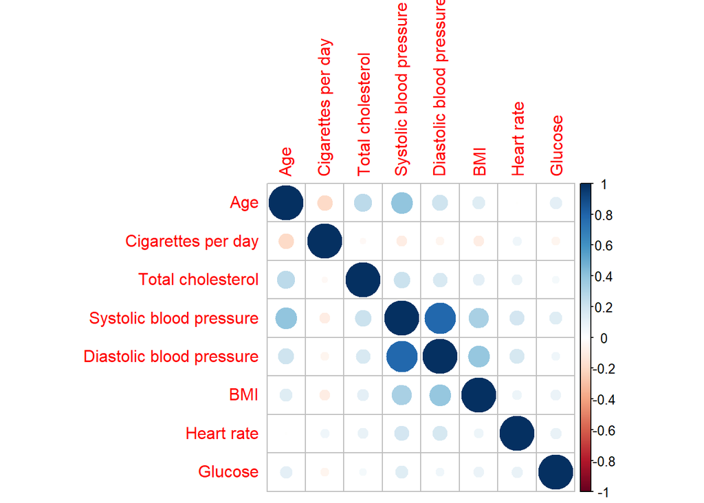

```r
library (corrplot)
cleaned_data %>%
  select(where(is.numeric)) %>%
  cor (use = "complete.obs")  %>%
  corrplot()
```

*Корреляционные матрицы удобно использовать, чтобы быстро выявить сильно корреллирующие переменные. Недостаток корреляционных исследований в том, что они не могут ответить на вопрос о причинно-следственной связи и для расчёта коэффициента корреляции можно использовать только две переменные.*